# Neotoma Resources with Seminole Cultural Affiliation

April 2024

## Introduction

### About [Neotoma](https://neotomadb.org)

[Neotoma](https://neotomadb.org) was formed in 2006 as a federated database constituted by a set of more specialized paleoecological databases. This means that Neotoma brings together paleoecological data from a range of proxy types (e.g., pollen, charcoal, testate amoebae), regions (e.g., North America, Latin America, Europe), and time periods (e.g., Pliocene, Pleistocene, Holocene). Neotoma incorporates data collected over more than 150 years.

## Neotoma and Native Lands

Neotoma contains records from upwards of 22,000 sites. Many of these sites are affiliated with native lands. A subset of these sites comes from federally recognized reservations in the United States.

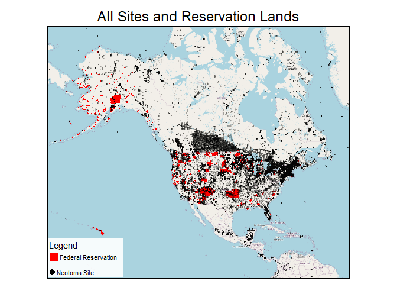

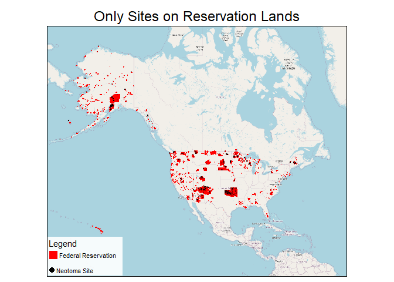

The following table counts the number of sites (n) from Neotoma that fall within the borders of federally recognized reservations. Overall, there are 692 sites on 105 reservations. Florida has many Neotoma sites.

| NAME | n |
| --- | --- |
| Navajo Nation | 177 |
| Menominee | 61 |
| Chickasaw | 30 |
| Cheyenne-Arapaho | 28 |
| Hopi | 21 |
| White Earth | 19 |
| Kenaitze | 18 |
| Blackfeet | 15 |
| Cherokee | 15 |
| Kiowa-Comanche-Apache-Fort Sill Apache | 13 |

[output cut: 95 more lines]

## Neotoma Resources in Florida

The following map shows the location of Neotoma sites in Florida. There are (as of April 2024) 432 distinct sites, but some of them may be close together, so 432 dots are not necessarily distinguishable on the map. Also be aware that there may be points on the coast of Florida that aren’t captured within the borders of the Florida polygon used on this page. Overlaid on this map are lands protected by the top five biggest land managers in Florida (Forest Service; Regional Water Districts; State Fish and Wildlife; Other state; and National Park Service).

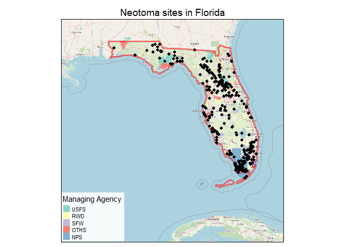

And the following table lists some information about those sites.

| siteid | sitename | sitedescription |
| --- | --- | --- |
| 10 | Site 1 (Cohen unpublished) |  |
| 229 | Barchampe Lake | Sinkhole pond. Physiography: Gulf Coastal Plain, level. Surrounding vegetation: pine/oak forest. |
| 312 | Buck Lake | Sinkhole lake. Physiography: Lake Wales Ridge, gently rolling. Surrounding vegetation: orange orchards. |
| 324 | Camel Lake | Sinkhole lake. Physiography: level, Gulf Coastal Plain. Surrounding vegetation: Pinus palustris/Quercus laevis forest. |
| 535 | USGS Gage 15 | Marsh. Physiography: flat little to no relief. Surrounding vegetation: Typha with Eichomia/Poaceae/Carex. |
| 536 | USGS Gage 34 | Marsh. Physiography: flat little to no relief. Surrounding vegetation: Cladium with Nymphaea/Sagittaria. |
| 537 | USGS Gage 65 | Marsh. Physiography: flat little to no relief. Surrounding vegetation: Cladium with Nymphaea and Utricularia. |
| 538 | USGS Gage 63 | Marsh. Physiography: flat little to no relief. Surrounding vegetation: Cladium/Sagittaria/Nymphaea. |
| 540 | USGS Gage 62 | Marsh. Physiography: flat little to no relief. Surrounding vegetation: Cladium/Sagittaria/Nym/Typ/Utricularia. |
| 541 | Water Conservation Area 3A, Site 3-4-1 | Marsh. Physiography: flat little to no relief. Surrounding vegetation: Cladium/Typha/Sagittaria/Nymphaea. |

[output cut: 422 more lines]

We can further inspect the sites by the kinds of data they contain. Neotoma sites in Florida concern pollen, vertebrate fauna, diatom, water chemistry, macroinvertebrate, loss-on-ignition, charcoal, X-ray fluorescence (XRF), biomarker, geochemistry, insect and plant macrofossil. The following map shows the distribution of Neotoma datasets by dataset type for the top five most abundant dataset types in Florida.

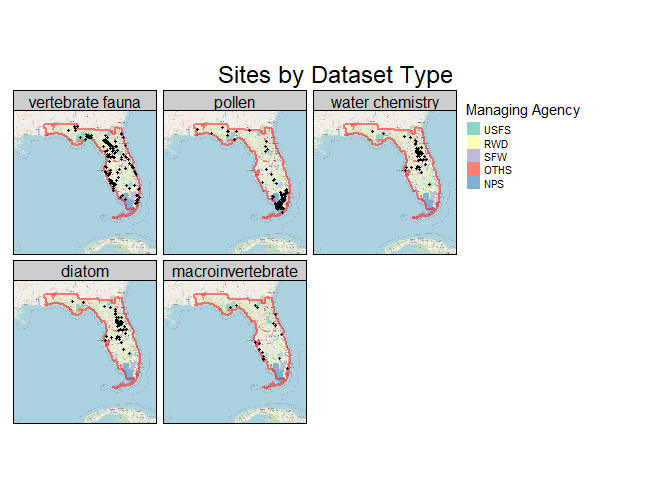

| data.datasettype | n |
| --- | --- |
| pollen | 212 |
| vertebrate fauna | 175 |
| diatom | 103 |
| water chemistry | 57 |
| macroinvertebrate | 20 |
| loss-on-ignition | 5 |
| charcoal | 2 |
| X-ray fluorescence (XRF) | 1 |
| biomarker | 1 |
| geochemistry | 1 |

[output cut: 2 more lines]

Physical specimens are not typically preserved for all types of datasets, and Neotoma doesn’t have perfect information about the disposition of the physical specimens even when they do exist. What we do know is that for Neotoma data collected from Florida, the Florida Museum of Natural History, Academy of Natural Sciences, Philadelphia, University of Florida, Florida State Museum, American Museum of Natural History, National Museum of Natural History and University of South Florida hold physical specimens.

| repository | types | n |
| --- | --- | --- |
| Florida Museum of Natural History | vertebrate fauna | 96 |
| Academy of Natural Sciences, Philadelphia | diatom | 40 |
| University of Florida | vertebrate fauna | 22 |
| Florida State Museum | vertebrate fauna | 2 |
| American Museum of Natural History | vertebrate fauna | 1 |
| National Museum of Natural History | vertebrate fauna | 1 |
| University of South Florida | vertebrate fauna | 1 |

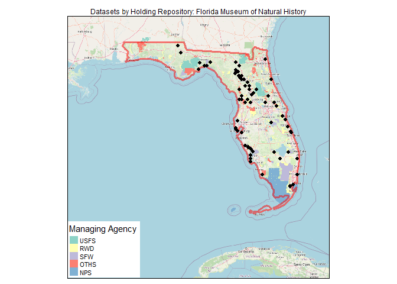

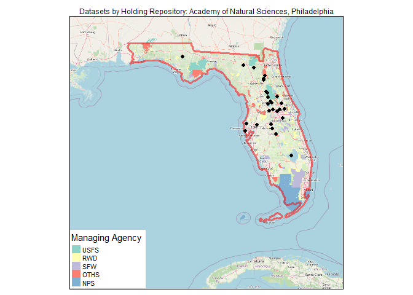

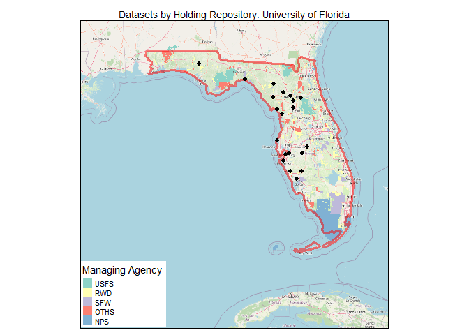